# Bootstrapping hw

Author

Chita Chaaban

Published

January 1, 2026

# **Workshop Week 10**

## **Section 1: Back to Linear and Logistic Models**

Loading the data:

```r
data <- read.csv("diabetes_subsample.csv")
```

**QUESTION 1:**

check_model() is a function from the performance package that quickly checks whether a regression model is a good fit for the data. It creates a set of diagnostic plots (like linearity, residuals, outliers, etc.) in one step, instead of running many separate tests.

**QUESTION 2: Linear model**

```r
# Load packages for model diagnostics
library(performance)
library(easystats)
# STEP 1: Fit a linear model predicting blood glucose from BMI
model_bmi <- lm(blood_glucose_level ~ bmi, data = data)

# STEP 2: Display model results
summary(model_bmi)
```

```
Call:
lm(formula = blood_glucose_level ~ bmi, data = data)

Residuals:
    Min      1Q  Median      3Q     Max
-65.798 -38.601   2.748  20.399 161.399

Coefficients:
            Estimate Std. Error t value Pr(>|t|)
(Intercept) 130.5910     5.4627  23.906   <2e-16 ***
bmi           0.2932     0.1945   1.507    0.132
---
Signif. codes:  0 '***' 0.001 '**' 0.01 '*' 0.05 '.' 0.1 ' ' 1

Residual standard error: 41.18 on 998 degrees of freedom
Multiple R-squared:  0.002271,  Adjusted R-squared:  0.001271
F-statistic: 2.272 on 1 and 998 DF,  p-value: 0.1321
```

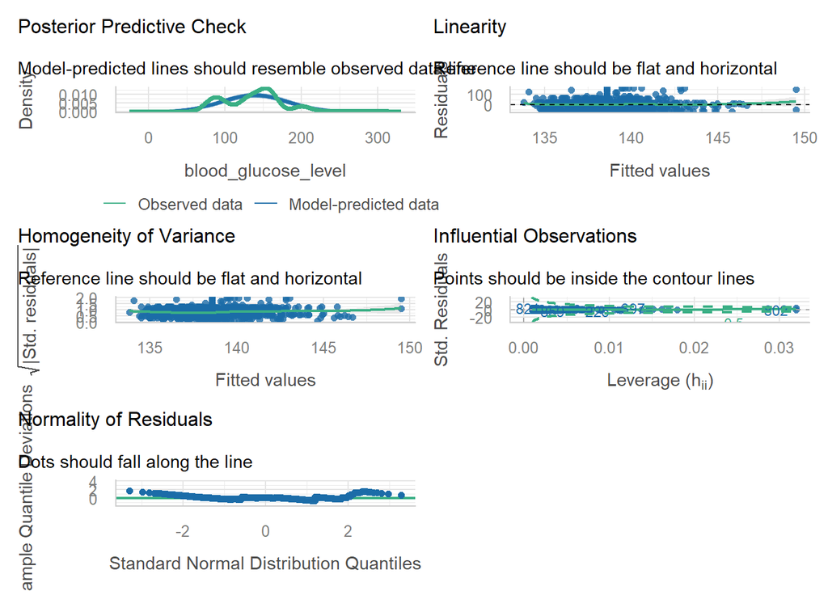

```r
# STEP 3: Check model assumptions and diagnostics
check_model(model_bmi)
```

Interpretationns:

**Posterior Predictive Check:** The predicted distribution matches closely the observed data, indicating that the model captures the overall shape of blood glucose levels well.

**Linearity:** The residuals follow a somewhat flat pattern, suggesting no strong violation of the linearity assumption, although the narrow spread reflects a weak relationship.

**Homogeneity of Variance:** The residuals appear evenly distributed across fitted values, indicating no clear heteroskedasticity.

**Influential Observations:** Most points lie within the contour lines, showing that no individual observations are exerting strong influence on the model.

**Normality of Residuals:** The residuals align closely with the reference line, suggesting approximate normality.

General interpretation: The model satisfies the main assumptions, but the very limited variation in fitted values indicates that BMI has little explanatory power for blood glucose, making the model statistically acceptable but not very informative.

## **Section 2: Logistic regression**

**QUESTION 3:**

```r
# STEP 1: Fit a logistic regression model predicting diabetes
# using BMI, age, and gender
model_log <- glm(diabetes ~ bmi + age + gender,
                 family = binomial,
                 data = data)

# STEP 2: Display model results
summary(model_log)
```

```
Call:
glm(formula = diabetes ~ bmi + age + gender, family = binomial,
    data = data)

Coefficients:
              Estimate Std. Error z value Pr(>|z|)
(Intercept)  -7.634194   0.730457 -10.451  < 2e-16 ***
bmi           0.081614   0.016057   5.083 3.72e-07 ***
age           0.052016   0.007324   7.102 1.23e-12 ***
genderMale    0.495948   0.236105   2.101   0.0357 *
genderOther -11.022431 535.411199  -0.021   0.9836
---
Signif. codes:  0 '***' 0.001 '**' 0.01 '*' 0.05 '.' 0.1 ' ' 1

(Dispersion parameter for binomial family taken to be 1)

    Null deviance: 605.08  on 999  degrees of freedom
Residual deviance: 503.75  on 995  degrees of freedom
AIC: 513.75

Number of Fisher Scoring iterations: 12
```

The intercept is large and negative (−7.63, p < 0.001), indicating that the baseline probability of diabetes is extremely low for the reference group (female, with BMI and age at zero), though this has little substantive meaning.

BMI has a positive and significant effect (*B* = 0.0816, p < 0.001), meaning that each one-unit increase in BMI increases the log-odds of diabetes; in odds terms, this corresponds to about an 8.5% increase in odds (exp(0.0816) ≈ 1.085). Age also has a positive and highly significant effect (*B* = 0.0520, p < 0.001), implying that each additional year increases the odds of diabetes by about 5.3% (exp(0.0520) ≈ 1.053).

Gender shows that males have higher odds of diabetes compared to females (*B* = 0.496, p = 0.035), corresponding to about 64% higher odds (exp(0.496) ≈ 1.64). The “other” gender category is not significant (*B*= −11.02, p = 0.984), suggesting no reliable effect, likely due to very few observations in that group. In conclusion the model shows that BMI and age are strong predictors of diabetes, and males face a higher risk compared to females.

QUESTION 4:

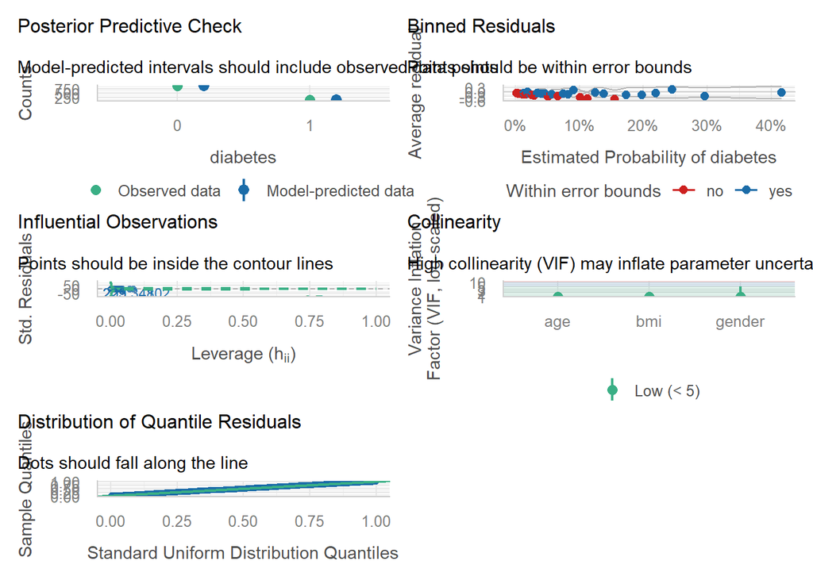

```r
# Setting figure size for better visualization
#| fig-width: 12
#| fig-height: 8

# STEP 1: Check assumptions and diagnostics of the logistic model
check_model(model_log)
```

Interpretations:

**- Posterior Predictive Check (Model fit):** The predicted values overlap closely with the observed data, indicating that the logistic model’s structure is appropriate and reproduces the distribution of diabetes in the sample well.

**- Binned Residuals (Linearity of the logit):** Most points fall within the gray error bounds without forming a clear curve or U-shape, suggesting that the relationship between the predictors and the log-odds of diabetes is adequately linear.

**- Collinearity (No multicollinearity):** All VIF values are low and remain below critical thresholds, indicating that the predictors are not highly correlated and each contributes distinct information to the model.

**- Influential Observations (Outliers):** The observations are largely within the contour lines, showing that no single data point is exerting disproportionate influence on the model estimates.

**- Distribution of Quantile Residuals (The overall fit):** The residuals align closely with the reference line, indicating that the model fits the data well and that its distributional assumptions are reasonable.

**The Conclusion:**

The model satisfies the key assumptions of logistic regression: the logit is approximately linear, the model fits the data distribution well, there is no multicollinearity, and no influential outliers. Therefore, the model provides a reliable representation of the relationship between BMI, age, gender, and diabetes.

**QUESTION 5**

1. Linear Probability Model (LPM)

```r
# We run a linear regression on a binary outcome (diabetes = 0/1)
# This is the Linear Probability Model (LPM)

model_lpm <- lm(diabetes ~ bmi + age + gender, data = data)

# Display results
summary(model_lpm)
```

```
Call:
lm(formula = diabetes ~ bmi + age + gender, data = data)

Residuals:
     Min       1Q   Median       3Q      Max
-0.33879 -0.13982 -0.07489 -0.00519  0.97634

Coefficients:
              Estimate Std. Error t value Pr(>|t|)
(Intercept) -0.1934527  0.0378743  -5.108 3.91e-07 ***
bmi          0.0054419  0.0013749   3.958 8.09e-05 ***
age          0.0028092  0.0004167   6.741 2.66e-11 ***
genderMale   0.0379739  0.0175728   2.161   0.0309 *
genderOther -0.1097273  0.2748431  -0.399   0.6898
---
Signif. codes:  0 '***' 0.001 '**' 0.01 '*' 0.05 '.' 0.1 ' ' 1

Residual standard error: 0.2746 on 995 degrees of freedom
Multiple R-squared:  0.0842,    Adjusted R-squared:  0.08052
F-statistic: 22.87 on 4 and 995 DF,  p-value: < 2.2e-16
```

The intercept is negative and significant (−0.193, p < 0.001), indicating that the baseline probability of diabetes for the reference group (female, with BMI and age equal to zero) is very low, though this value has limited actual substantive meaning. BMI has a positive and significant effect (*B* = 0.0054, p < 0.001), meaning that each one-unit increase in BMI increases the probability of diabetes by about 0.54 percentage points.

Age is also positive and highly significant (*B* = 0.0028, p < 0.001), implying that each additional year increases the probability of diabetes by about 0.28 percentage points. As for Gender, it shows that males have a higher probability of diabetes compared to females (*B*= 0.0380, p = 0.031), corresponding to an increase of about 3.8 percentage points. In conclusion, BMI and age have small but significant effects on the probability of diabetes, and males face a slightly higher probability compared to females, though the model explains only a limited share of variation (R² ≈ 0.08).

2. Visualization of the model

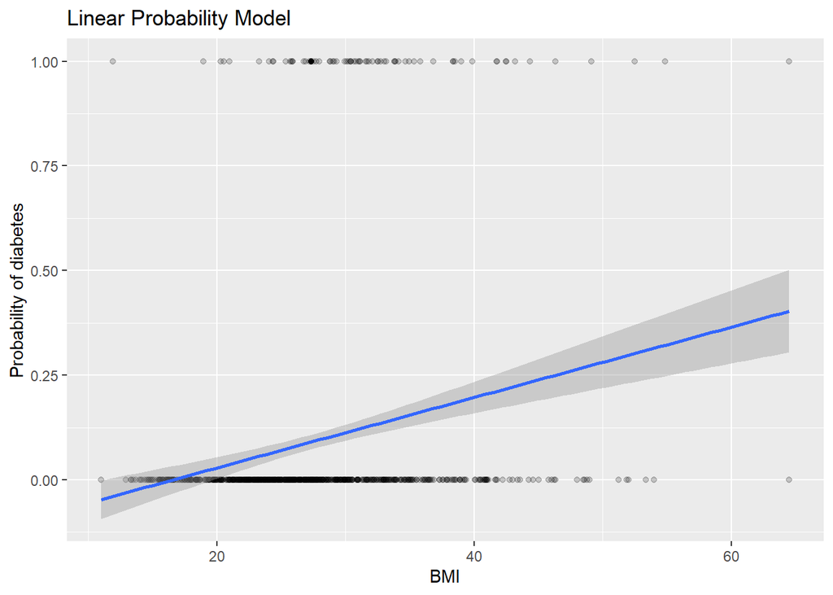

```r
library(ggplot2)
# Plot of the relationship between BMI and diabetes using a linear model
ggplot(data, aes(x = bmi, y = diabetes)) +
  geom_point(alpha = 0.2) +
  geom_smooth(method = "lm") +
  labs(title = "Linear Probability Model",
       x = "BMI",
       y = "Probability of diabetes")
```

The plot shows a positive linear relationship between BMI and the probability of diabetes, with the predicted probability increasing steadily as BMI rises. However, since the regression line extends below 0 for low BMI values and could eventually exceed 1 for high values, the Linear Probability Model can produce unrealistic probabilities and does not fully respect the bounded nature of the outcome.

3. Average Marginal Effects (AME)

```r
# Load package to compute marginal effects
library(marginaleffects)
# Compute average marginal effects from logistic model
ame <- avg_slopes(model_log)

# Display results
ame
```

```
   Term       Contrast Estimate Std. Error     z Pr(>|z|)    S    2.5 %
 age    dY/dX           0.00377   0.000545  6.92   <0.001 37.7  0.00270
 bmi    dY/dX           0.00592   0.001156  5.12   <0.001 21.6  0.00365
 gender Male - Female   0.03670   0.017724  2.07   0.0384  4.7  0.00196
 gender Other - Female -0.07479   0.010374 -7.21   <0.001 40.7 -0.09512
   97.5 %
  0.00484
  0.00818
  0.07144
 -0.05446

Type: response
```

**QUESTION 6:**

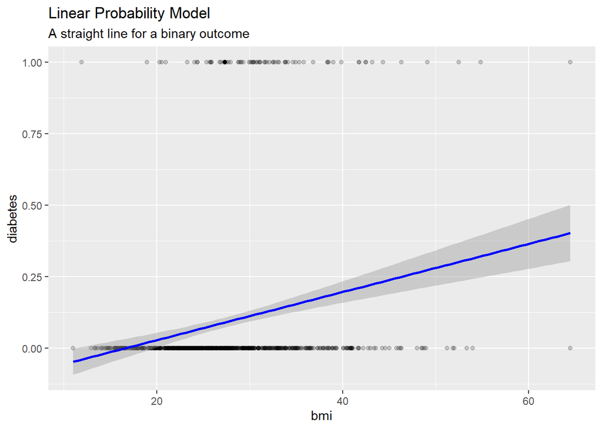

```r
library(ggplot2)

# 1. The Linear Approach (Straight line)
p1 <- ggplot(data, aes(x = bmi, y = diabetes)) +
  geom_point(alpha = 0.2) +
  geom_smooth(method = "lm", color = "blue") +
  labs(title = "Linear Probability Model", subtitle = "A straight line for a binary outcome")

# 2. The Logistic Approach (S-Curve)
p2 <- ggplot(data, aes(x = bmi, y = diabetes)) +
  geom_point(alpha = 0.2) +
  geom_smooth(method = "glm", method.args = list(family = "binomial"), color = "red") +
  labs(title = "Logistic Model", subtitle = "The S-curve (sigmoïd)")

p1
```

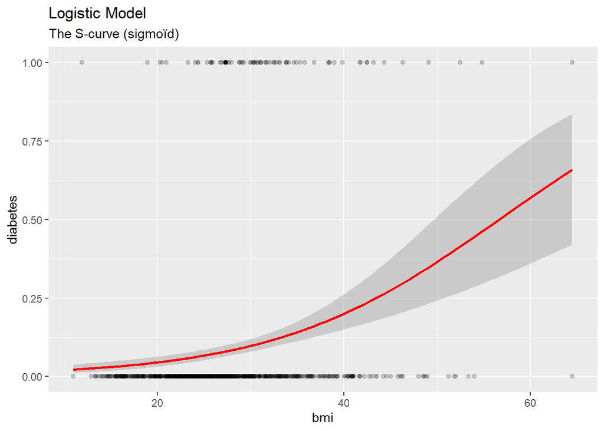

```r
p2
```

The LPM graph shows a positive relationship between BMI and diabetes. As BMI increases, the predicted probability increases in a straight line. However, the line goes slightly below 0 at low BMI values, which is not realistic since probabilities cannot be negative. The relationship is simple but not fully appropriate for a binary outcome.

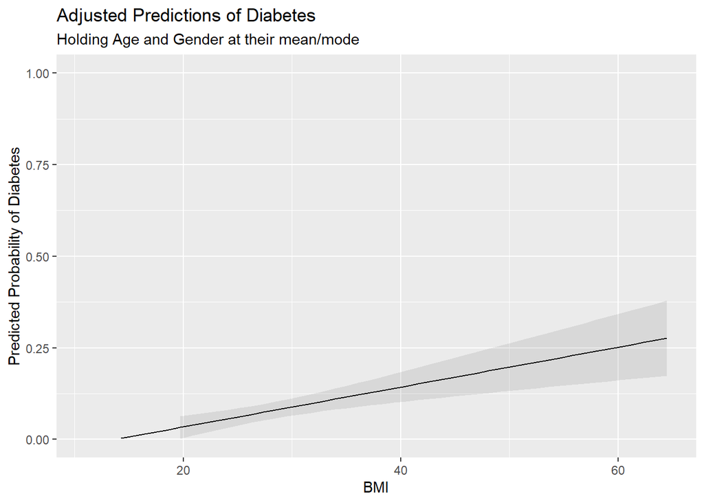

```r
library(marginaleffects)
# Visualizing the effect of BMI while "controlling" for Age and Gender
#Linear model:
model_lin <- lm(diabetes ~ bmi + age + gender, data = data)
plot_predictions(model_lin, condition = "bmi") +
  ylim(0, 1) +
  labs(
    title = "Adjusted Predictions of Diabetes",
    subtitle = "Holding Age and Gender at their mean/mode",
    y = "Predicted Probability of Diabetes",
    x = "BMI"
  )
```

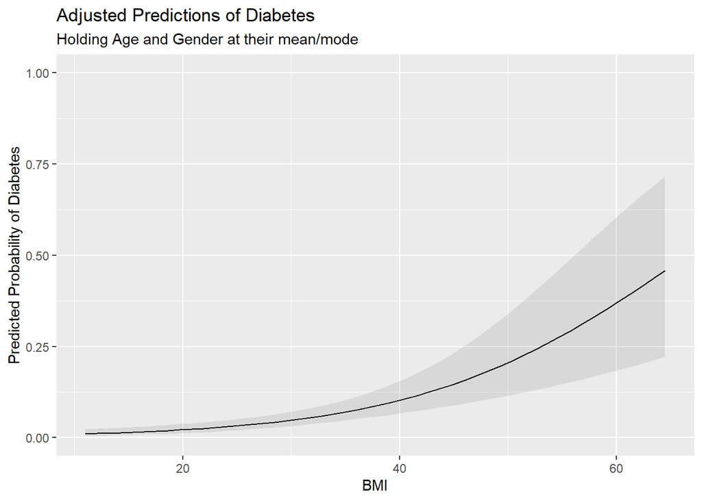

```r
#Logistic:
model_log <- glm(diabetes ~ bmi + age + gender, family = binomial, data = data)
plot_predictions(model_log, condition = "bmi") +
  ylim(0, 1) +
  labs(
    title = "Adjusted Predictions of Diabetes",
    subtitle = "Holding Age and Gender at their mean/mode",
    y = "Predicted Probability of Diabetes",
    x = "BMI"
  )
```

The Adjusted Linear Model graph shows a steady increase in the probability of diabetes as BMI increases. The relationship is linear, with the probability rising gradually from very low levels to around 0.25–0.30 at higher BMI values. The effect of BMI is constant across the range.

The Adjusted Logistic Model graph on the other hand shows a curved relationship. The probability increases slowly at low BMI, then more sharply after around BMI 40, and reaches much higher values at the upper end. The increase is not constant and becomes stronger at higher BMI levels.

Both models show that higher BMI is associated with higher probability of diabetes. However, the logistic model captures the stronger increase at higher BMI, while the linear model underestimates this change.

**QUESTION 7:**

To communicate the results, I would avoid technical measures like odds ratios and instead use simple probability terms, such as percentage increases in risk. I would also use clear visualizations, especially a curved plot showing how the probability of diabetes increases with BMI, since it makes the relationship easier to understand.

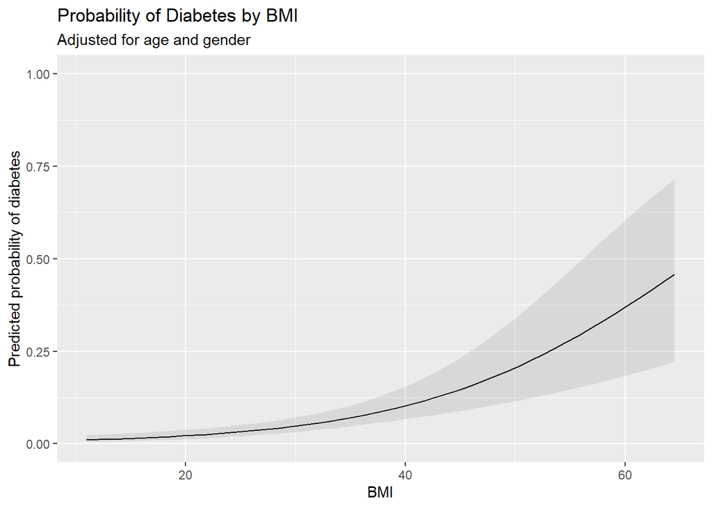

```r
# Load package for marginal effects and predictions
library(marginaleffects)

# STEP 1: Fit logistic model (same as before)
model_log <- glm(diabetes ~ bmi + age + gender,
                 family = binomial,
                 data = data)

# STEP 2: Plot predicted probabilities of diabetes across BMI
# while holding other variables constant
plot_predictions(model_log, condition = "bmi") +
  ylim(0, 1) +
  labs(
    title = "Probability of Diabetes by BMI",
    subtitle = "Adjusted for age and gender",
    y = "Predicted probability of diabetes",
    x = "BMI"
  )
```

I think it would be important to show adjusted results rather than raw relationships, so that the effect of BMI is presented while accounting for age and gender. This avoids misleading interpretations.

I would tell people that BMI is a simple measure based on height and weight that helps indicate whether someone is in a healthy range. Generally, a BMI between about 18.5 and 24.9 is considered healthy, while higher values indicate overweight or obesity. I would explain that as BMI increases, the risk of diabetes also increases, and this risk rises more sharply at higher BMI levels.

## **Section 2: Bootstrapping**

**QUESTION 8**

Bootstrapped confidence intervals are better when the data is limited or not well-behaved. For example, if the sample size is small or the data is skewed or has outliers, the usual methods that rely on assumptions might not be reliable. In those cases, bootstrapping is useful because it does not rely on strong assumptions about the distribution. Instead, it uses the data itself to estimate how much the results could vary.

It is also more helpful when we want to understand uncertainty in a more realistic way. Rather than focusing on whether a result is “significant,” it shows a range of possible values, which makes it easier to understand how precise or uncertain the estimate is.

**QUESTION 9**

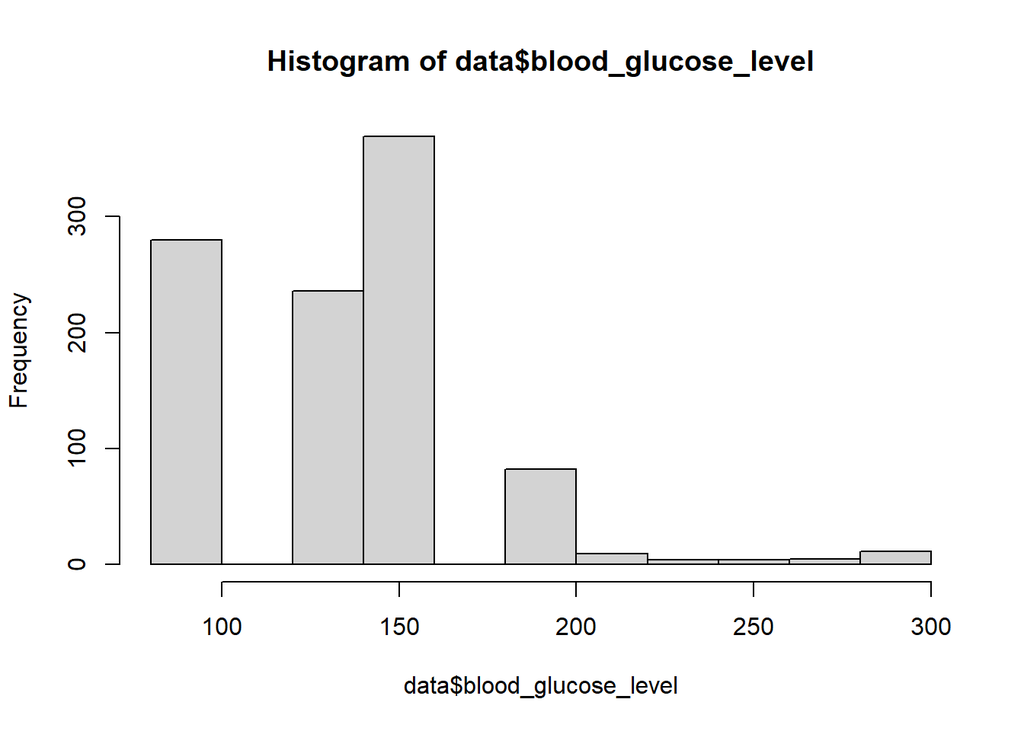

```r
hist(data$blood_glucose_level)
```

The distribution of blood glucose levels is right-skewed, with most observations concentrated around lower to moderate values and a few high values extending the tail to the right.

```r
library(tidyverse)
# STEP 1: Create an empty "bucket" (vector) to hold our results
# We will do this 500 times
n_iterations <- 500
glucose_estimates <- numeric(n_iterations)

# STEP 2: The Loop (The "Manual" work)
for (i in 1:n_iterations) {

  # A. Create a "Resample" (Pick rows at random with replacement)
  boot_data <- data[sample(nrow(data), replace = TRUE), ]

  # B. Run the model on THIS specific simulated dataset
  boot_model <- glm(diabetes ~ blood_glucose_level + age,
                    family = "binomial", data = boot_data)

  # C. Save the Glucose coefficient into our "bucket" at position i
  glucose_estimates[i] <- coef(boot_model)["blood_glucose_level"]

  # For pedagogu: Print progress every 100 times so students see it working
  if(i %% 100 == 0) print(paste("Simulation number", i, "complete!"))
}
```

```
[1] "Simulation number 100 complete!"
[1] "Simulation number 200 complete!"
[1] "Simulation number 300 complete!"
[1] "Simulation number 400 complete!"
[1] "Simulation number 500 complete!"
```

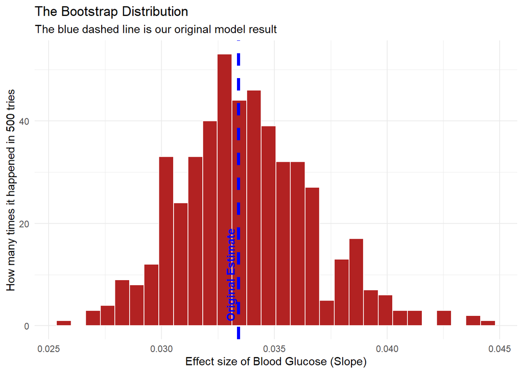

```r
# STEP 3: Turn the bucket into a table for plotting
results_df <- data.frame(estimate = glucose_estimates)


# STEP 4: Visualize the results
# 1. First, get the "Original Result" from your main model
model_glucose = glm(diabetes ~ blood_glucose_level + age,
                    family = "binomial", data = data)
original_slope <- coef(model_glucose)["blood_glucose_level"]

# 2. Plot the histogram
ggplot(results_df, aes(x = estimate)) +
  # The bars: represent the 500 "simulated" worlds
  geom_histogram(fill = "firebrick", color = "white", bins = 30) +
  # The line: represents the "original" result from our real data
  geom_vline(xintercept = original_slope,
             color = "blue",
             linewidth = 1.5,
             linetype = "dashed") +

  # Add a label to know what the blue line is
  annotate("text", x = original_slope, y = 10, label = "Original Estimate",
           color = "blue", angle = 90, vjust = -0.5, fontface = "bold") +

  labs(title = "The Bootstrap Distribution",
       subtitle = "The blue dashed line is our original model result",
       x = "Effect size of Blood Glucose (Slope)",
       y = "How many times it happened in 500 tries") +
  theme_minimal()
```

We first create an empty vector called glucose_estimates that will store the coefficient of blood glucose, and we set it to run 500 times. Next, we run a loop from 1 to 500. In each iteration, we randomly resample the data with replacement, meaning some rows can appear multiple times and others not at all.

On each of these new simulated datasets, I run the same logistic regression model predicting diabetes using blood glucose and age. Then, I extract the coefficient for blood glucose and store it in the vector. I also print a message every 100 iterations just to track progress. After the loop, I convert all the stored coefficients into a data frame so I can plot them. Then, I run the original model on the real data and extract the original blood glucose coefficient.

Finally, I plot a histogram of all the bootstrapped estimates and add a vertical dashed blue line to show the original estimate.

Interpretation of the graph: The graph shows the distribution of the blood glucose coefficient across 500 simulated samples. Most of the estimates are concentrated around the same value, and the original estimate lies near the center of this distribution. This means the result is stable and does not change much across different samples. The effect of blood glucose is consistently positive.

**QUESTION 10:**

- Research question: Does smoking history affect the probability of diabetes?
- Hypothesis: Individuals with a history of smoking have a higher probability of diabetes compared to non-smokers.

The Bootstrap loop:

```r
# Create a new variable: 1 = smoker, 0 = non-smoker
data$smoker <- ifelse(data$smoking_history == "never", 0, 1)

# Create an empty vector to store the smoking effect
# We will repeat the process 500 times
n_iterations <- 500
smoking_estimates <- numeric(n_iterations)

# Repeat the analysis 500 times
for (i in 1:n_iterations) {

  # A. Create a resample (randomly pick rows with replacement)
  boot_data <- data[sample(nrow(data), replace = TRUE), ]

  # B. Run the logistic regression on this resampled dataset
  boot_model <- glm(diabetes ~ smoker + age + bmi,
                    family = "binomial",
                    data = boot_data)

  # C. Store the coefficient for smoker (compared to non-smoker)
  smoking_estimates[i] <- coef(boot_model)["smoker"]

  # Print progress every 100 iterations
  if(i %% 100 == 0) print(paste("Simulation number", i, "complete!"))
}
```

```
[1] "Simulation number 100 complete!"
[1] "Simulation number 200 complete!"
[1] "Simulation number 300 complete!"
[1] "Simulation number 400 complete!"
[1] "Simulation number 500 complete!"
```

```r
# Convert the stored coefficients into a data frame for plotting
results_df <- data.frame(estimate = smoking_estimates)
```

The original estimate / Model:

```r
# Run the model on the original dataset
model_smoking <- glm(diabetes ~ smoker + age + bmi,
                     family = "binomial",
                     data = data)

# Extract the original coefficient
original_slope <- coef(model_smoking)["smoker"]
```

**Visualization:**

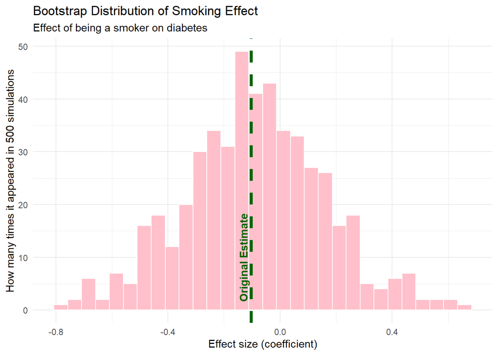

```r
# Plot the distribution of the bootstrapped estimates
ggplot(results_df, aes(x = estimate)) +

  # Histogram: shows variation across simulations
  geom_histogram(fill = "pink", color = "white", bins = 30) +

  # Vertical dashed line: original estimate
  geom_vline(xintercept = original_slope,
             color = "darkgreen",
             linewidth = 1.5,
             linetype = "dashed") +

  # Label for the original estimate
  annotate("text", x = original_slope, y = 10,
           label = "Original Estimate",
           color = "darkgreen", angle = 90, vjust = -0.5, fontface = "bold") +

  labs(title = "Bootstrap Distribution of Smoking Effect",
       subtitle = "Effect of being a smoker on diabetes",
       x = "Effect size (coefficient)",
       y = "How many times it appeared in 500 simulations") +

  theme_minimal()
```

The graph shows the distribution of the smoking effect across 500 simulated samples. The estimates are spread out and include both negative and positive values, with many of them close to zero. The original estimate is also close to zero and falls within this range. This suggests that the effect of being a smoker on diabetes is not consistent across samples and is relatively small. There is no clear evidence of a strong or stable effect.

The results do not strongly support the hypothesis that smokers have a higher probability of diabetes.